# Model Q extremes

Beni Stocker

2024-09-03

Libraries and functions.

```r
library(tidyverse)
library(here)
library(visdat)
library(lubridate)
library(cowplot)
library(cwd)
library(rgeco)

low_pass_filter <- function(vec, tau){

  # pad with the first year
  vec <- c(vec[1:365], vec)

  vec_lpf <- rep(NA, length(vec))
  vec_lpf[1] <- vec[1]
  for (idx in 2:length(vec)){
    vec_lpf[idx] <- vec_lpf[idx - 1] + (1/tau) * (vec[idx] - vec_lpf[idx - 1])
  }

  # remove pad again
  vec_lpf <- vec_lpf[366:length(vec_lpf)]

  return(vec_lpf)
}
```

## Data

Load data. This is not contained in the repo because not public (yet).

```r
df <- read_rds(here("data-raw/Catchmentdata_subset.rds"))
```

Subset to only one catchment for explorations here. Subset years to avoid NAs.

```r
df_sub <- df |>
  mutate(year = year(date)) |>
  filter(catchmentnr == 2034 & year >= 1963 & year < 2023)
```

No data is missing.

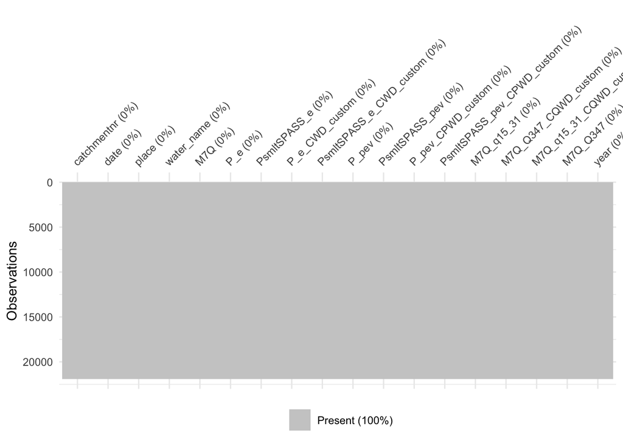

```r
vis_miss(df_sub, warn_large_data = FALSE)
```

## Get Q-extreme events

Defining as where M7Q_Q347 < 0.

```r
df_sub <- df_sub |>
  mutate(qex = ifelse(M7Q_Q347 < 0, 1, 0))
```

Get low-flow extreme events.

```r
inst_qex <- rgeco::get_consecutive(
  df_sub |>
    pull(qex),
  merge_threshold = 7,  # pool events that are less than 7 days apart
  leng_threshold = 15,
  do_merge = FALSE
)

# add start and end dates
inst_qex <- inst_qex |>
  mutate(
    start = df_sub$date[inst_qex$idx_start],
    end = df_sub$date[inst_qex$idx_start + inst_qex$len - 1]
  )
```

## Get CWD

Re-calculate to CWD events.

First, determine `doy_reset` based on wettest month. Here across all catchments to re-set on the same date each year for all catchments (could be done more clever).

The wettest month (number) is:

```r
df_msc <- df_sub |>
  mutate(month = month(date)) |>
  group_by(month) |>
  summarise(PsmltSPASS_pev = mean(PsmltSPASS_pev, na.rm = TRUE))

wettest_month <- df_msc |>
  arrange(desc(PsmltSPASS_pev)) |>
  slice(1) |>
  pull(month)

wettest_month
```

```
## [1] 11
```

Visualise for sanity check.

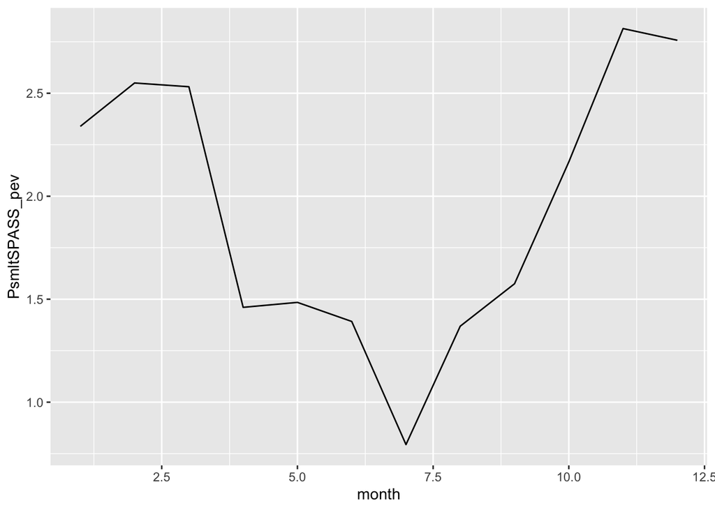

```r
df_msc |>
  ggplot(aes(month, PsmltSPASS_pev)) +
  geom_line()
```

```r
out_cwd <- cwd(
  df_sub,
  varname_wbal = "PsmltSPASS_pev",
  varname_date = "date",
  thresh_terminate = 0,
  thresh_drop = 0.1,
  doy_reset = yday(ymd(paste0("2001-", as.character(wettest_month),"-01")))
)
```

Retain only long CWD events (longer than 25 days).

```r
out_cwd$inst <- out_cwd$inst |>
  filter(len > 25)

# Add cwd to df
df_sub <- df_sub |>
  left_join(
    out_cwd$df |>
      select(date, deficit),
    join_by("date")
  )
```

## Visualise with events

Add low-pass-filtered CWD with a tau of 90 days (arbitrary, more or less).

```r
df_sub <- df_sub |>
  mutate(deficit_lpf = low_pass_filter(deficit, tau = 90))
```

For subset of years. The blue curve is the low-pass-filtered CWD with `tau = 90`.

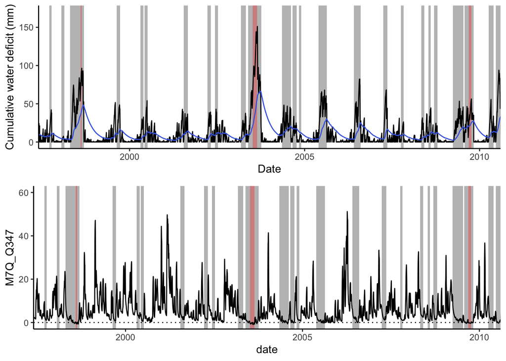

```r
# CWD with CWD-events (grey)
gg1 <- ggplot() +
  geom_rect(
    data = out_cwd$inst,
    aes(xmin = date_start, xmax = date_end, ymin = -99, ymax = 99999),
    fill = rgb(0,0,0,0.3),
    color = NA
    ) +
  geom_rect(
    data = inst_qex,
    aes(
      xmin = start,
      xmax = end,
      ymin = -99,
      ymax = 99999
    ),
    fill = rgb(1,0,0,0.3)
  ) +
  geom_line(
    aes(
      x = date,
      y = deficit
    ),
    data = df_sub
  ) +
  geom_line(
    aes(
      x = date,
      y = deficit_lpf
    ),
    data = df_sub,
    color = "royalblue"
  ) +
  coord_cartesian(
    ylim = c(0, 170),
    xlim = c(ymd("1998-01-01"), ymd("2009-12-31"))
    )  +
  theme_classic() +
  labs(x = "Date", y = "Cumulative water deficit (mm)")

# smoothed Q - Q347? with Qex events (red) and CWD events (grey)
gg2 <- ggplot() +
  geom_rect(
    data = out_cwd$inst,
    aes(xmin = date_start, xmax = date_end, ymin = -99, ymax = 99999),
    fill = rgb(0,0,0,0.3),
    color = NA
    ) +
  geom_rect(
    data = inst_qex,
    aes(
      xmin = start,
      xmax = end,
      ymin = -99,
      ymax = 99999
    ),
    fill = rgb(1,0,0,0.3)
  ) +
  geom_line(
    aes(
      x = date,
      y = M7Q_Q347
    ),
    data = df_sub
  ) +
  coord_cartesian(
    ylim = c(0, 60),
    xlim = c(ymd("1998-01-01"), ymd("2009-12-31"))
    )  +
  geom_hline(aes(yintercept = 0), linetype = "dotted") +
  theme_classic()

plot_grid(
  gg1,
  gg2,
  ncol = 1
)
```

## Modelling

Modelling the binary variable defined above (`qex`) with logistic regression. First, some visualisations.

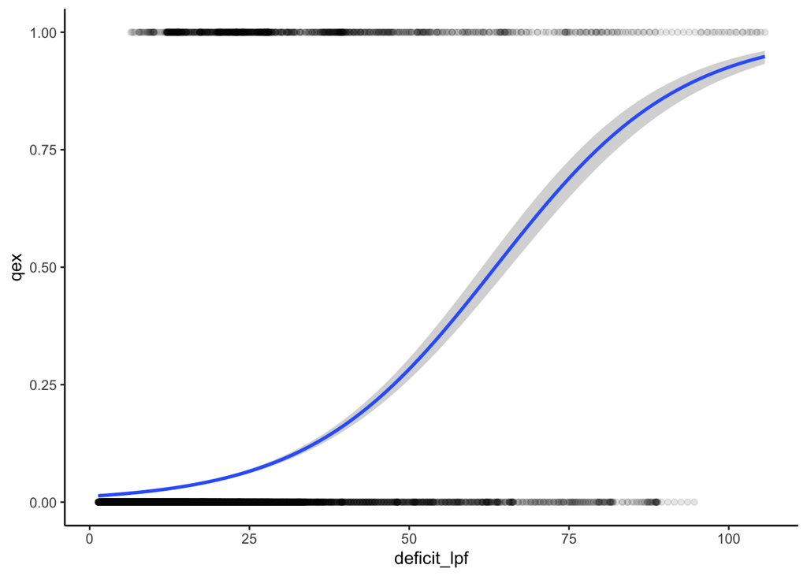

```r
# logistic regression doesn't work - it's always predicting FALSE
df_sub |>
  drop_na(deficit, qex) |>
  ggplot(aes(deficit_lpf, qex)) +
  geom_point(alpha = 0.1) +
  stat_smooth(
    method = "glm",
    method.args = list(family = binomial)
    ) +
  theme_classic()
```

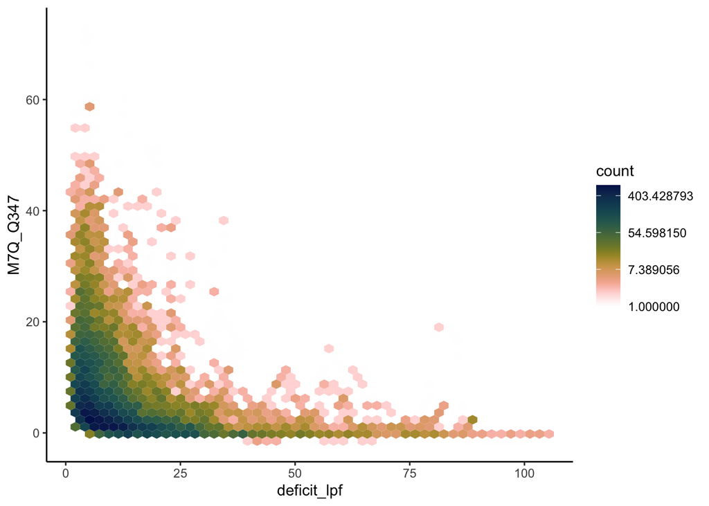

```r
df_sub |>
  filter(catchmentnr == 2034) |>
  ggplot(aes(deficit_lpf, M7Q_Q347)) +
  geom_hex(bins = 50) +
  khroma::scale_fill_batlowW(trans = "log", reverse = TRUE) +
  theme_classic()
```

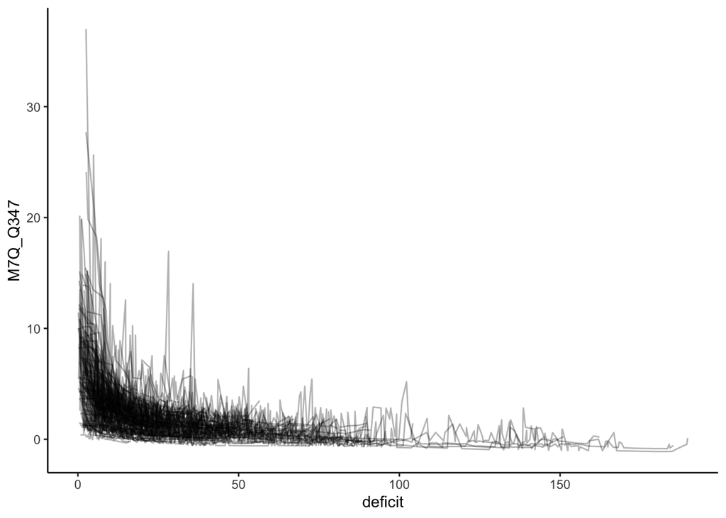

```r
out_cwd$df |>
  filter(iinst %in% unique(out_cwd$inst$iinst)) |>
  ggplot(aes(deficit, M7Q_Q347, group = iinst)) +
  geom_line(alpha = 0.3) +
  theme_classic()
```

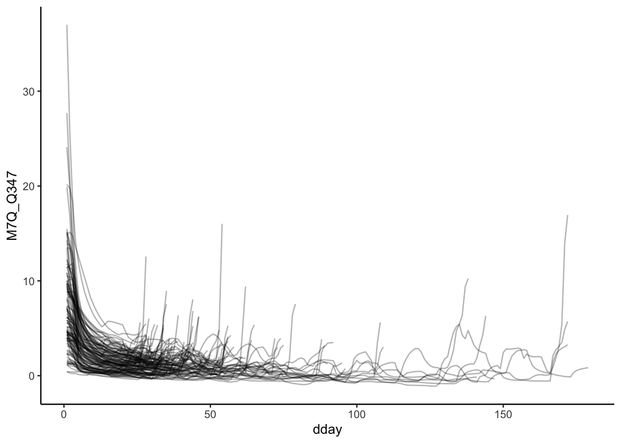

```r
out_cwd$df |>
  filter(iinst %in% unique(out_cwd$inst$iinst)) |>
  ggplot(aes(dday, M7Q_Q347, group = iinst)) +
  geom_line(alpha = 0.3) +
  theme_classic()
```

Fit a model with `glm(family = binomial(link = logit))`.

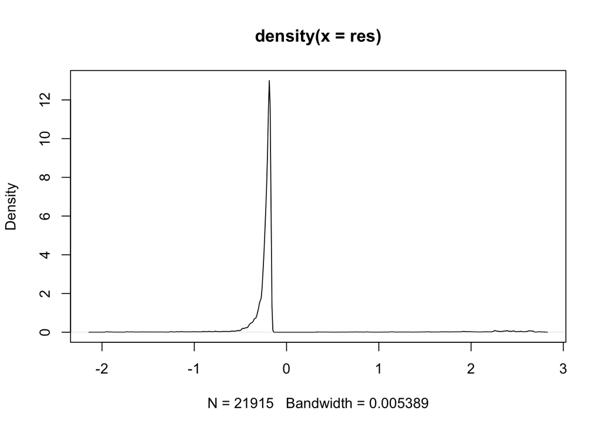

```r
logmod <- glm(
  qex ~ deficit_lpf,
  family = binomial(link = logit),
  data = df_sub
  )

summ <- summary(logmod)
res <- resid(logmod, type = "deviance")

plot(density(res))
```

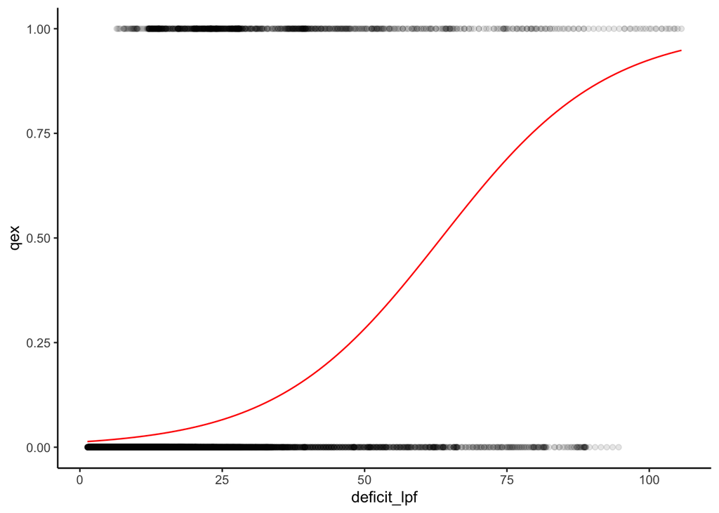

```r
rmse <- sqrt(mean(res^2))

beta <- coef(logmod)

df_sub |>
  drop_na(deficit_lpf, qex) |>
  ggplot(aes(deficit_lpf, qex)) +
  geom_point(alpha = 0.1) +
  geom_function(
    fun = function(x) exp(beta[1] + beta[2] * x)/(1 + exp(beta[1] + beta[2] * x)),
    color = "red") +
  theme_classic()
```

**To do**: Use an appropriate model skill metric. I guess the best would be to get the area under the [(receiver-operating characteristic) curve](https://en.wikipedia.org/wiki/Receiver_operating_characteristic).

For demo, I use the RMSE here with residuals calculated as `resid(..., type = "deviance")`. Wrap this into a function of tau - the characteristic time scale of the low-pass-filtered CWD.

```r
get_rmse <- function(ddf, tau){

  # low pass filter
  ddf$deficit_lpf <- low_pass_filter(ddf$deficit, tau)

  # model as a function of low-pass filtered
  logmod <- glm(
    qex ~ deficit_lpf,
    family = binomial(link = logit),
    data = ddf
    )

  # get residuals and RMSE
  res <- resid(logmod, type = "deviance")
  rmse <- sqrt(mean(res^2))

  # but: not sure what a good metric is: https://rpubs.com/benhorvath/glm_diagnostics

  return(rmse)
}

get_rmse(df_sub, 90)
```

```
## [1] 0.5301245
```

Evaluate the goodness of fit of a fitted logistic regression model as a function of tau.

```r
df_rmse <- tibble(tau = seq(1, 150, by = 2)) |>
  rowwise() |>
  mutate(rmse = get_rmse(df_sub, tau))
```

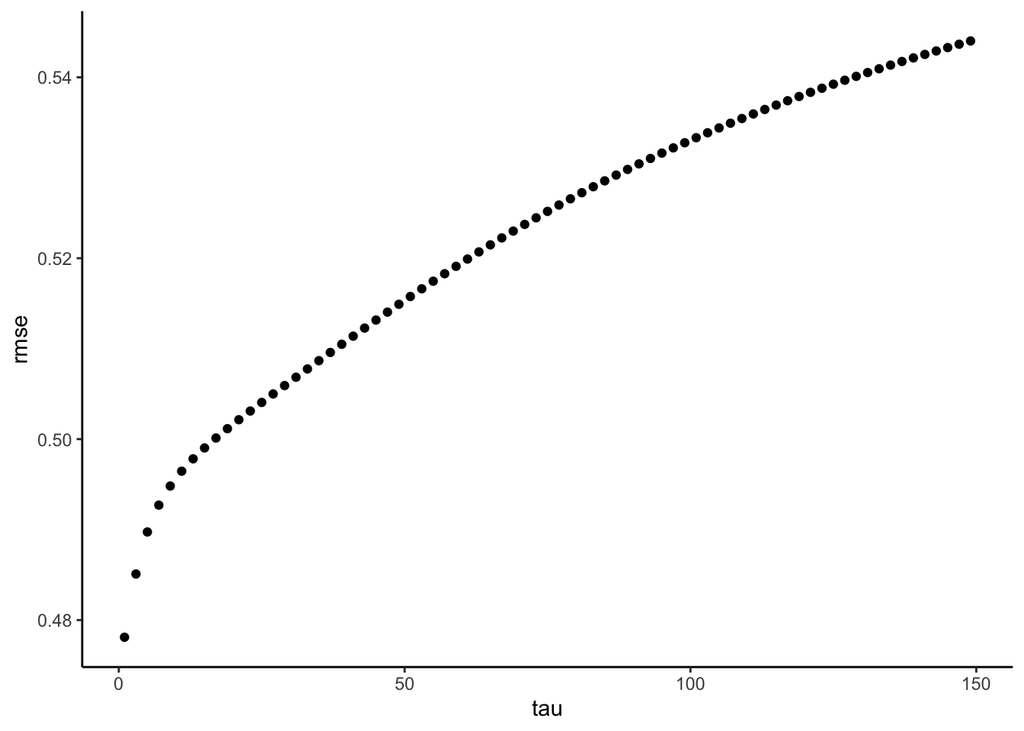

```r
df_rmse |>
  ggplot(aes(tau, rmse)) +
  geom_point() +
  theme_classic()
```

Apparently, this doesn’t work - no minimum. Or: best is to use tau = 1 (no filter).